# Minerals and the rock cycle

Dr. Ahmad Redaa

2024-09-04

# Minerals

- **Definition:**
  - Naturally occurring, inorganic solids with a definite chemical composition and crystal structure.
  - Examples: Quartz, Feldspar, Mica.
- **Characteristics:**
  - **Chemical Composition:** Fixed chemical formula (e.g., NaCl for Halite).
  - **Crystal Structure:** Regular, repeating arrangement of atoms.
  - **Formation:** Typically formed through geological processes like crystallization from magma or precipitation from solutions.

# **Rocks:**

- **Definition:**
  - Solid aggregates composed of (one or more) minerals.
  - Examples: Granite (composed of Quartz, Feldspar, and Mica), Limestone (composed of Calcite).
- **Characteristics:**
  - **Composition:** Can include a mixture of minerals and/or mineraloids.
  - **Texture:** Varies based on mineral composition, grain size, and formation process.
  - **Formation:** Formed through various geological processes such as cooling and solidification of magma (igneous rocks), compression and cementation of sediments (sedimentary rocks), or alteration of existing rocks (metamorphic rocks).

# Rocks vs. Minerals

- **Composition:**
  - **Minerals:** Single substance with a specific chemical composition.
  - **Rocks:** Mixture of multiple minerals or mineraloids.
- **Structure:**
  - **Minerals:** Defined crystal structure.
  - **Rocks:** Aggregates of minerals with varying structures.
- **Formation:**
  - **Minerals:** Crystallize from molten material, form through evaporation, or precipitate from aqueous solutions.
  - **Rocks:** Formed through geological processes involving minerals or organic matter.

# The Rock Cycle and Involved Processes

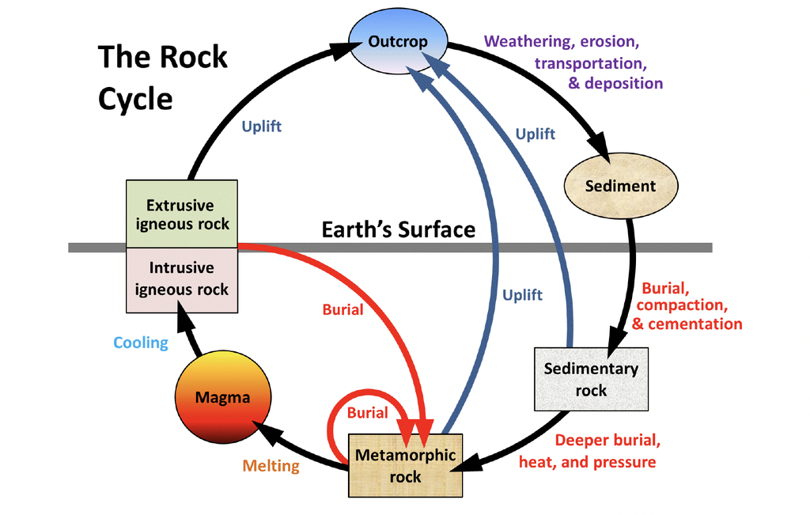

The Rock Cycle, Source: [Steven, E. (2015)](https://openlibrary-repo.ecampusontario.ca/jspui/handle/123456789/402)

# Summary